# Finding Manchester City a New Striker

[figure not shown]

## Motivation

After the 2020/2021 English Premier League, the top level of English soccer/football, season, champions Manchester City said goodbye to club legend Sergio Aguero, who spent ten years at the club and in that time became their top goalscorer of all time scoring 260 goals for the club. Losing him meant their would be a void in the team and that City would need to dip into the transfer market to find his replacement, however they were unable to do this last season and remain in the hunt for a new striker as the current season comes to a close. Given that he is Manchester City's leading scorer of all time you probably could have guessed his position is a striker, which would be correct. Using popular stat collecting website TransferMarkt I will find which of the worlds best and most promising strikers would be the best fit for Manchester City, taking into account playstyle, build, age, cost, and more. In the table just below you can see the 20 top options from the worlds top five leagues, which include: the English Premier League, the Spanish La Liga, the Italian Serie A, the French Ligue 1, and the German Bundesliga.

```python
#Imports for necessary libraries and downloaded data set from Kaggle.

import pandas as pd
import numpy as np
import matplotlib.pyplot as plt
import seaborn as sns
import statsmodels.api as sm
from statsmodels.formula.api import ols
from sklearn.linear_model import LinearRegression
import opendatasets as od

od.download("https://www.kaggle.com/datasets/kriegsmaschine/soccer-players-values-and-their-statistics?
            select=transfermarkt_fbref_201920.csv")
```

```
Skipping, found downloaded files in "./soccer-players-values-and-their-statistics" (use force=True to force download)
```

Here I read the data from over 2500 players and picked out the top 20 options and since many international players have non English characters and accents in their names I decieded to fix that up so the table was more readable.

```python
#Turing the csv file to a Dataframe and extracting the top 20 striker options from that Dataframe. I also replaced the
#characters that were unreadable with plain English characters.

Players = pd.read_csv("soccer-players-values-and-their-statistics/transfermarkt_fbref_201920.csv", ";")
Strikers = pd.DataFrame(columns = Players.columns)
Strikers = Strikers.append(Players.loc[Players['player'] == 'Robert Lewandowski'])
Strikers = Strikers.append(Players.loc[Players['player'] == 'Erling HĂĄland'])
Strikers = Strikers.append(Players.loc[Players['player'] == 'Lautaro MartĂnez'])
Strikers = Strikers.append(Players.loc[Players['player'] == 'JoĂŁo FĂ©lix'])
Strikers = Strikers.append(Players.loc[Players['player'] == 'Karim Benzema'])
Strikers = Strikers.append(Players.loc[Players['player'] == 'Cristiano Ronaldo'])
Strikers = Strikers.append(Players.loc[Players['player'] == 'Kylian MbappĂ©'])
Strikers = Strikers.append(Players.loc[Players['player'] == 'Rafael LeĂŁo'])
Strikers = Strikers.append(Players.loc[Players['player'] == 'Victor Osimhen'])
Strikers = Strikers.append(Players.loc[Players['player'] == 'Harry Kane'])
Strikers = Strikers.append(Players.loc[Players['player'] == 'Pierre-Emerick Aubameyang'])
Strikers = Strikers.append(Players.loc[Players['player'] == 'Romelu Lukaku'])
Strikers = Strikers.append(Players.loc[Players['player'] == 'DuĹˇan VlahoviÄ‡'])
Strikers = Strikers.append(Players.loc[Players['player'] == 'Gerard Moreno'])
Strikers = Strikers.append(Players.loc[Players['player'] == 'Luis SuĂˇrez'])
Strikers = Strikers.append(Players.loc[Players['player'] == 'Antoine Griezmann'])
Strikers = Strikers.append(Players.loc[Players['player'] == 'Ciro Immobile'])
Strikers = Strikers.append(Players.loc[Players['player'] == 'Edinson Cavani'])
Strikers = Strikers.append(Players.loc[Players['player'] == 'Timo Werner'])
Strikers = Strikers.append(Players.loc[Players['player'] == 'Luka JoviÄ‡'])
Strikers = Strikers.replace(to_replace = "Erling HĂĄland", value = "Erling Haaland")
Strikers = Strikers.replace(to_replace = "Lautaro MartĂnez", value = "Lautaro Martinez")
Strikers = Strikers.replace(to_replace = "JoĂŁo FĂ©lix", value = "Joao Felix")
Strikers = Strikers.replace(to_replace = "Kylian MbappĂ©", value = "Kylian Mbappe")
Strikers = Strikers.replace(to_replace = "Rafael LeĂŁo", value = "Rafael Leao")
Strikers = Strikers.replace(to_replace = "DuĹˇan VlahoviÄ‡", value = "Dusan Vlahovic")
Strikers = Strikers.replace(to_replace = "Luis SuĂˇrez", value = "Luis Suarez")
Strikers = Strikers.replace(to_replace = "Luka JoviÄ‡", value = "Luka Jovic")
Strikers = Strikers.replace(to_replace = "AtlĂ©tico Madrid", value = "Atletico Madrid")
Strikers
```

|  | Column1 | player | nationality | position | squad | ... | Attendance | CL | WinCL | CLBestScorer | Season |
| --- | --- | --- | --- | --- | --- | --- | --- | --- | --- | --- | --- |
| 283 | 1410 | Robert Lewandowski | pl POL | FW | Bayern Munich | ... | 57353 | 1 | 0 | 1.0 | 201920# |
| 686 | 1051 | Erling Haaland | no NOR | FW | Dortmund | ... | 57297 | 1 | 0 | 0.0 | 201920# |
| 1056 | 1572 | Lautaro Martinez | ar ARG | FW | Inter | ... | 41558 | 1 | 0 | 0.0 | 201920# |
| 196 | 832 | Joao Felix | pt POR | FW,MF | Atletico Madrid | ... | 42,236 | 1 | 0 | 0.0 | 201920# |
| 1925 | 266 | Karim Benzema | fr FRA | FW | Real Madrid | ... | 45833 | 1 | 0 | 0.0 | 201920# |
| 1093 | 2157 | Cristiano Ronaldo | pt POR | FW | Juventus | ... | 25102 | 1 | 0 | 0.0 | 201920# |
| 1858 | 1602 | Kylian Mbappe | fr FRA | FW | Paris S-G | ... | 47517 | 1 | 0 | 0.0 | 201920# |
| 1550 | 1384 | Rafael Leao | pt POR | FW | Milan | ... | 34078 | 0 | 0 | 0.0 | 201920# |
| 1298 | 1853 | Victor Osimhen | ng NGA | FW | Lille | ... | 36404 | 0 | 0 | 0.0 | 201920# |
| 2341 | 1242 | Harry Kane | eng ENG | FW | Tottenham | ... | 43757 | 0 | 0 | NaN | 201920# |
| 79 | 136 | Pierre-Emerick Aubameyang | ga GAB | FW | Arsenal | ... | 47589 | 0 | 0 | 0.0 | 201920# |
| 1055 | 1479 | Romelu Lukaku | be BEL | FW | Inter | ... | 41558 | 1 | 0 | 0.0 | 201920# |
| 836 | 2619 | Dusan Vlahovic | rs SRB | FW | Fiorentina | ... | 22486 | 0 | 0 | 0.0 | 201920# |
| 2504 | 1704 | Gerard Moreno | es ESP | FW,MF | Villarreal | ... | 11321 | 0 | 0 | NaN | 201920# |
| 265 | 2414 | Luis Suarez | uy URU | FW | Barcelona | ... | 54223 | 1 | 0 | 0.0 | 201920# |
| 253 | 1007 | Antoine Griezmann | fr FRA | FW | Barcelona | ... | 54223 | 1 | 0 | 0.0 | 201920# |
| 1139 | 1154 | Ciro Immobile | it ITA | FW | Lazio | ... | 26363 | 1 | 0 | 0.0 | 201920# |
| 1844 | 475 | Edinson Cavani | uy URU | FW | Paris S-G | ... | 47517 | 1 | 0 | 0.0 | 201920# |
| 1920 | 2656 | Timo Werner | de GER | FW | RB Leipzig | ... | 28819 | 1 | 0 | 0.0 | 201920# |
| 1932 | 1218 | Luka Jovic | rs SRB | FW | Real Madrid | ... | 45833 | 1 | 0 | 0.0 | 201920# |

20 rows × 400 columns

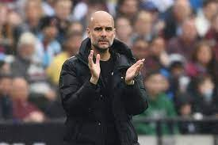

```python
#After extracting the strikers from all of the players I extracted the specific statistics that I would use to analyze
#the players.

StrikersStats = Strikers[['player', 'value', 'age', 'height', 'squad', 'minutes', 'goals', 'assists',
                          'goals_per90', 'goals_assists_per90', 'xg', 'shots_total', 'shots_on_target_pct',
                          'goals_per_shot', 'xg_net', 'passes', 'passes_pct', 'sca_per90', 'tackles', 'tackles_won',
                          'pressures', 'pressure_regain_pct', 'blocked_passes', 'interceptions', 'dribbles',
                          'dribbles_completed_pct', 'miscontrols', 'dispossessed', 'ball_recoveries', 'aerials_won',
                          'aerials_lost']]
StrikersStats
```

|  | player | value | age | height | squad | ... | miscontrols | dispossessed | ball_recoveries | aerials_won | aerials_lost |
| --- | --- | --- | --- | --- | --- | --- | --- | --- | --- | --- | --- |
| 283 | Robert Lewandowski | 56000000 | 30 | 185 | Bayern Munich | ... | 84 | 62 | 105 | 62 | 47 |
| 686 | Erling Haaland | 72000000 | 19 | 194 | Dortmund | ... | 32 | 13 | 44 | 21 | 23 |
| 1056 | Lautaro Martinez | 64000000 | 21 | 174 | Inter | ... | 86 | 60 | 132 | 26 | 62 |
| 196 | Joao Felix | 81000000 | 19 | 180 | Atletico Madrid | ... | 40 | 18 | 86 | 16 | 48 |
| 1925 | Karim Benzema | 32000000 | 31 | 184 | Real Madrid | ... | 59 | 42 | 126 | 28 | 48 |
| 1093 | Cristiano Ronaldo | 60000000 | 34 | 187 | Juventus | ... | 69 | 50 | 112 | 37 | 38 |
| 1858 | Kylian Mbappe | 180000000 | 20 | 178 | Paris S-G | ... | 44 | 43 | 69 | 4 | 4 |
| 1550 | Rafael Leao | 20000000 | 20 | 188 | Milan | ... | 33 | 30 | 69 | 30 | 33 |
| 1298 | Victor Osimhen | 27000000 | 20 | 186 | Lille | ... | 81 | 48 | 113 | 94 | 154 |
| 2341 | Harry Kane | 120000000 | 26 | 188 | Tottenham | ... | 52 | 43 | 92 | 64 | 123 |
| 79 | Pierre-Emerick Aubameyang | 56000000 | 30 | 187 | Arsenal | ... | 58 | 39 | 125 | 37 | 59 |
| 1055 | Romelu Lukaku | 68000000 | 26 | 191 | Inter | ... | 72 | 69 | 106 | 83 | 73 |
| 836 | Dusan Vlahovic | 16000000 | 19 | 190 | Fiorentina | ... | 67 | 56 | 88 | 38 | 60 |
| 2504 | Gerard Moreno | 16000000 | 27 | 180 | Villarreal | ... | 95 | 47 | 133 | 54 | 85 |
| 265 | Luis Suarez | 28000000 | 32 | 182 | Barcelona | ... | 38 | 30 | 66 | 5 | 7 |
| 253 | Antoine Griezmann | 96000000 | 28 | 176 | Barcelona | ... | 38 | 20 | 128 | 24 | 30 |
| 1139 | Ciro Immobile | 40000000 | 29 | 185 | Lazio | ... | 83 | 54 | 142 | 24 | 68 |
| 1844 | Edinson Cavani | 20000000 | 32 | 184 | Paris S-G | ... | 12 | 6 | 24 | 4 | 6 |
| 1920 | Timo Werner | 64000000 | 23 | 181 | RB Leipzig | ... | 79 | 50 | 161 | 9 | 28 |
| 1932 | Luka Jovic | 22000000 | 21 | 182 | Real Madrid | ... | 13 | 5 | 15 | 10 | 12 |

20 rows × 31 columns

I will now split the relevant columns into sub tables to focus on each one of the overall atributes and the stats that will be useful to look at in determining who is best in each of the categories I talked about above. The four broad categories I used are scoring, physcial attributes, keeping possession, and out of possession work. I did not include anything about their current team or value because that is something that can be considered secondary when in comes down to it and will likely be a tie breaker if necessary. Something to note is that some players have significantly lower minutes than others and that can be due to a number of reasons. Some of those reasons include but are not limited to injury, being younger so still being integrated into the first team, and specifically in the case of Erling Haaland being transfered mid season in the January transfer window.

```python
#Here I broke the Dataframe with only the necessary players and stats into the four categories that would be looked at
#when deciding on a transfer target.

Scoring = StrikersStats[['player', 'minutes', 'goals', 'goals_per90', 'xg', 'shots_total', 'shots_on_target_pct',
                         'goals_per_shot' ,'xg_net']]
Physical = StrikersStats[['player', 'value', 'age', 'height', 'aerials_won', 'aerials_lost']]
Possession = StrikersStats[['player', 'minutes', 'assists', 'passes', 'passes_pct', 'sca_per90', 'dribbles',
                            'dribbles_completed_pct', 'miscontrols', 'dispossessed']]
OffBall = StrikersStats[['player', 'minutes', 'tackles', 'tackles_won', 'pressures', 'pressure_regain_pct',
                         'blocked_passes', 'interceptions', 'ball_recoveries']]
```

### Scoring

The number one job of any striker is to be scoring goals and that is why I am looking at this metric first. Most of the stats regarding scoring are pretty straight forward. The reason we care about goals per 90 is because that is how long a game lasts and it only takes into account the minutes that are actually played, meaning that if someone is subbed off or on it won't over count their minutes like goals per game would. The other stat that may be unfamiliar is xg which stands for expected goals. This stat takes in numerous factors such as distance, position of defenders, type and speed of pass, type of shot, shot angles, and more. With this you get xg net which shows if the player over or under performed what they were expected to do and would be 0 if they did exactly as expected.

```python
#Showing the scoring Dataframe sorted by the goal per 90 minutes stat.

Scoring.sort_values(by = 'goals_per90', ascending = False)
```

|  | player | minutes | goals | goals_per90 | xg | shots_total | shots_on_target_pct | goals_per_shot | xg_net |
| --- | --- | --- | --- | --- | --- | --- | --- | --- | --- |
| 283 | Robert Lewandowski | 2759 | 34 | 1.11 | 27.5 | 134 | 44.0 | 0.22 | 6.5 |
| 686 | Erling Haaland | 1063 | 13 | 1.10 | 8.1 | 35 | 57.1 | 0.37 | 4.9 |
| 1858 | Kylian Mbappe | 1513 | 18 | 1.07 | 17.1 | 88 | 55.7 | 0.20 | 0.9 |
| 1139 | Ciro Immobile | 3170 | 36 | 1.02 | 27.0 | 127 | 44.1 | 0.17 | 9.0 |
| 1093 | Cristiano Ronaldo | 2917 | 31 | 0.96 | 26.7 | 196 | 34.2 | 0.10 | 4.3 |
| 1920 | Timo Werner | 2795 | 28 | 0.90 | 22.3 | 117 | 50.4 | 0.21 | 5.7 |
| 265 | Luis Suarez | 1998 | 16 | 0.72 | 13.9 | 78 | 53.8 | 0.19 | 2.1 |
| 1055 | Romelu Lukaku | 2979 | 23 | 0.69 | 20.1 | 95 | 43.2 | 0.18 | 2.9 |
| 2341 | Harry Kane | 2587 | 18 | 0.63 | 10.5 | 78 | 43.6 | 0.21 | 7.5 |
| 79 | Pierre-Emerick Aubameyang | 3136 | 22 | 0.63 | 15.8 | 90 | 44.4 | 0.22 | 6.2 |
| 1925 | Karim Benzema | 3141 | 21 | 0.60 | 17.5 | 118 | 45.8 | 0.14 | 3.5 |
| 1844 | Edinson Cavani | 605 | 4 | 0.60 | 7.6 | 28 | 35.7 | 0.11 | -3.6 |
| 2504 | Gerard Moreno | 2744 | 18 | 0.59 | 13.4 | 85 | 37.6 | 0.20 | 4.6 |
| 1298 | Victor Osimhen | 2287 | 13 | 0.51 | 15.0 | 82 | 39.0 | 0.13 | -2.0 |
| 1056 | Lautaro Martinez | 2452 | 14 | 0.51 | 15.9 | 122 | 34.4 | 0.10 | -1.9 |
| 1932 | Luka Jovic | 430 | 2 | 0.42 | 2.2 | 12 | 25.0 | 0.17 | -0.2 |
| 1550 | Rafael Leao | 1404 | 6 | 0.38 | 4.9 | 45 | 33.3 | 0.13 | 1.1 |
| 836 | Dusan Vlahovic | 1499 | 6 | 0.36 | 7.9 | 64 | 26.6 | 0.08 | -1.9 |
| 253 | Antoine Griezmann | 2549 | 9 | 0.32 | 8.2 | 55 | 41.8 | 0.16 | 0.8 |
| 196 | Joao Felix | 1745 | 6 | 0.31 | 7.4 | 64 | 28.1 | 0.09 | -1.4 |

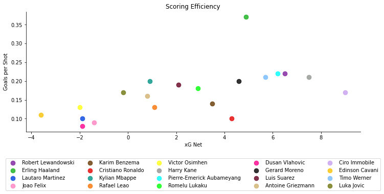

```python
#Created a color palette with a color for each player to be used in the plots below. Also made a plot with xG Net against
#goals per shot.

colors = ["purple", "green", "blue", "pink", "brown", "red", "teal", "orange", "yellow", "grey", \
          "cyan", "bright green", "hot pink", "black", "maroon", "tan", "lavender", "goldenrod", "sky blue", "olive"]
new_palette = sns.xkcd_palette(colors)
sns.lmplot(x="xg_net", y="goals_per_shot", data=Scoring, fit_reg=False, hue='player', \
               legend=False, palette=new_palette, size=4, aspect=2.5, scatter_kws={"s": 75})
plt.legend(loc=9, bbox_to_anchor=(0.5, -0.2), ncol=5)
plt.title('Scoring Efficiency')
plt.xlabel('xG Net')
plt.ylabel('Goals per Shot')
```

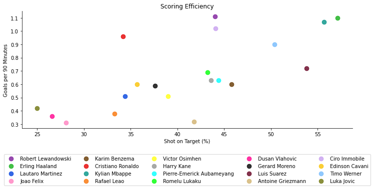

```python
#Created a plot with shot on target percentage against goals per 90 minutes.

sns.lmplot(x="shots_on_target_pct", y="goals_per90", data=Scoring, fit_reg=False, hue='player', \
               legend=False, palette=new_palette, size=4, aspect=2.5, scatter_kws={"s": 75})
plt.legend(loc=9, bbox_to_anchor=(0.5, -0.2), ncol=5)
plt.title('Scoring Efficiency')
plt.xlabel('Shot on Target (%)')
plt.ylabel('Goals per 90 Minutes')
```

Based on scoring alone the top 5 options should be: 1) Erling Haaland 2) Kylian Mbappe 3) Robert Lewandowski 4) Ciro Immobile 5) Timo Werner

### Possession

As I previously stated Pep's style involves keeping the ball for long periods of time to move the defense around, tire them out, and force them to make mistakes which can open up space. Players can adapt to different systems when the move teams but ideally you want them to have some ability to slot in quickly. If you watch City play and watch Pep you can see how upset and angry he gets when one of his players loses the ball especially when it is a result of carelessness. Again most of these stats are fairly clear as to what they are, but sca is something most people have not heard of. SCA is defined as being the two offensive actions that lead to a shot so that can be a dribble, a pass, or being fouled.

```python
#Showed possession dataframe and sorted by shot creating actions per 90 minutes.

Possession.sort_values(by = 'sca_per90', ascending = False)
```

|  | player | minutes | assists | passes | passes_pct | sca_per90 | dribbles | dribbles_completed_pct | miscontrols | dispossessed |
| --- | --- | --- | --- | --- | --- | --- | --- | --- | --- | --- |
| 1858 | Kylian Mbappe | 1513 | 5 | 671 | 76.8 | 5.41 | 115 | 51.3 | 44 | 43 |
| 1093 | Cristiano Ronaldo | 2917 | 5 | 1289 | 84.3 | 4.41 | 87 | 65.5 | 69 | 50 |
| 1550 | Rafael Leao | 1404 | 1 | 476 | 76.1 | 3.78 | 63 | 65.1 | 33 | 30 |
| 1920 | Timo Werner | 2795 | 8 | 1065 | 71.7 | 3.77 | 110 | 60.0 | 79 | 50 |
| 1056 | Lautaro Martinez | 2452 | 3 | 520 | 62.5 | 3.45 | 83 | 56.6 | 86 | 60 |
| 1844 | Edinson Cavani | 605 | 1 | 140 | 85.7 | 3.42 | 7 | 85.7 | 12 | 6 |
| 1925 | Karim Benzema | 3141 | 8 | 1329 | 84.2 | 3.38 | 72 | 54.2 | 59 | 42 |
| 265 | Luis Suarez | 1998 | 8 | 697 | 75.9 | 3.33 | 52 | 48.1 | 38 | 30 |
| 283 | Robert Lewandowski | 2759 | 4 | 783 | 75.6 | 3.33 | 106 | 56.6 | 84 | 62 |
| 1139 | Ciro Immobile | 3170 | 9 | 929 | 77.0 | 3.21 | 65 | 49.2 | 83 | 54 |
| 2504 | Gerard Moreno | 2744 | 5 | 1027 | 72.3 | 3.12 | 101 | 60.4 | 95 | 47 |
| 1055 | Romelu Lukaku | 2979 | 2 | 809 | 71.7 | 3.08 | 40 | 60.0 | 72 | 69 |
| 196 | Joao Felix | 1745 | 1 | 531 | 77.2 | 2.58 | 58 | 34.5 | 40 | 18 |
| 836 | Dusan Vlahovic | 1499 | 0 | 343 | 68.8 | 2.34 | 47 | 68.1 | 67 | 56 |
| 686 | Erling Haaland | 1063 | 2 | 236 | 73.7 | 2.12 | 27 | 44.4 | 32 | 13 |
| 253 | Antoine Griezmann | 2549 | 4 | 1147 | 81.5 | 2.08 | 37 | 48.6 | 38 | 20 |
| 2341 | Harry Kane | 2587 | 2 | 592 | 66.6 | 1.88 | 59 | 47.5 | 52 | 43 |
| 1298 | Victor Osimhen | 2287 | 4 | 368 | 63.0 | 1.73 | 36 | 41.7 | 81 | 48 |
| 79 | Pierre-Emerick Aubameyang | 3136 | 3 | 888 | 68.9 | 1.61 | 49 | 51.0 | 58 | 39 |
| 1932 | Luka Jovic | 430 | 1 | 134 | 82.8 | 1.47 | 7 | 57.1 | 13 | 5 |

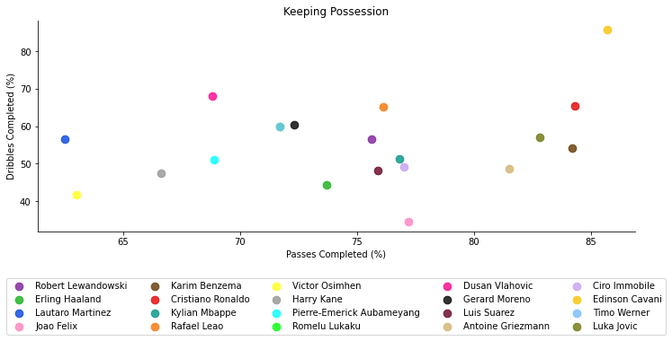

```python
#Created a plot with shot on pass completion percentage against dribble completion percentage.

sns.lmplot(x="passes_pct", y="dribbles_completed_pct", data=Possession, fit_reg=False, hue='player', \
               legend=False, palette=new_palette, size=4, aspect=2.5, scatter_kws={"s": 75})
plt.legend(loc=9, bbox_to_anchor=(0.5, -0.2), ncol=5)
plt.title('Keeping Possession')
plt.xlabel('Passes Completed (%)')
plt.ylabel('Dribbles Completed (%)')
```

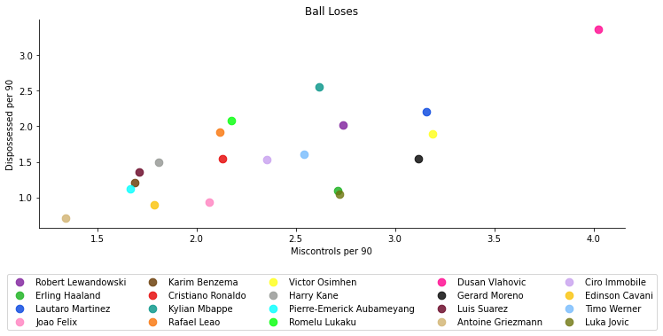

```python
#Created two new columns to look at the stats, miscontrols per 90 minutes and dispossed per 90 minutes instead of the raw
#numbers. Created a plot with miscontrols per 90 minutes against dispossessed per 90 minutes.

Possession['Miscontrols_per_90'] = pd.to_numeric(Possession['miscontrols'])/pd.to_numeric(Possession['minutes'])*90
Possession['Dispossessed_per_90'] = pd.to_numeric(Possession['dispossessed'])/pd.to_numeric(Possession['minutes'])*90
sns.lmplot(x="Miscontrols_per_90", y="Dispossessed_per_90", data=Possession, fit_reg=False, hue='player', \
               legend=False, palette=new_palette, size=4, aspect=2.5, scatter_kws={"s": 75})
plt.legend(loc=9, bbox_to_anchor=(0.5, -0.2), ncol=5)
plt.title('Ball Loses')
plt.xlabel('Miscontrols per 90')
plt.ylabel('Dispossessed per 90')
```

Based on these metric the top five options on keeping possession are:

1) Cristiano Ronaldo 2) Rafael Leao 3) Karim Benezma 4) Edinson Cavani 5) Luis Suarez

### Out of Possession

In order to get into the team in a Pep Guardiola squad you need to work hard when the team does not have the ball including pressing the defenders, cutting off passing lanes, and closing down space. Players also make a big effort to recovering the ball if they misplace a pass or get it stolen from them. Ball recoveries are a combination of many ways to get the ball including intercepting a pass, a successful tackle, a defensive action after a pass, or gathering possession in the defensive third.

```python
#Showed the out of possession actions dataframe.

OffBall
```

|  | player | minutes | tackles | tackles_won | pressures | pressure_regain_pct | blocked_passes | interceptions | ball_recoveries |
| --- | --- | --- | --- | --- | --- | --- | --- | --- | --- |
| 283 | Robert Lewandowski | 2759 | 19 | 12 | 387 | 31.8 | 13 | 4 | 105 |
| 686 | Erling Haaland | 1063 | 5 | 5 | 140 | 28.6 | 7 | 5 | 44 |
| 1056 | Lautaro Martinez | 2452 | 17 | 13 | 518 | 25.3 | 33 | 14 | 132 |
| 196 | Joao Felix | 1745 | 9 | 4 | 211 | 22.3 | 10 | 2 | 86 |
| 1925 | Karim Benzema | 3141 | 17 | 13 | 319 | 26.0 | 13 | 11 | 126 |
| 1093 | Cristiano Ronaldo | 2917 | 16 | 10 | 248 | 22.2 | 10 | 6 | 112 |
| 1858 | Kylian Mbappe | 1513 | 4 | 2 | 137 | 29.2 | 5 | 1 | 69 |
| 1550 | Rafael Leao | 1404 | 8 | 4 | 192 | 23.4 | 10 | 1 | 69 |
| 1298 | Victor Osimhen | 2287 | 8 | 5 | 439 | 31.0 | 16 | 12 | 113 |
| 2341 | Harry Kane | 2587 | 20 | 14 | 448 | 22.3 | 19 | 4 | 92 |
| 79 | Pierre-Emerick Aubameyang | 3136 | 39 | 24 | 573 | 22.7 | 57 | 9 | 125 |
| 1055 | Romelu Lukaku | 2979 | 11 | 4 | 257 | 23.3 | 9 | 2 | 106 |
| 836 | Dusan Vlahovic | 1499 | 4 | 2 | 240 | 25.0 | 8 | 7 | 88 |
| 2504 | Gerard Moreno | 2744 | 17 | 14 | 392 | 23.0 | 26 | 8 | 133 |
| 265 | Luis Suarez | 1998 | 3 | 2 | 191 | 25.1 | 12 | 1 | 66 |
| 253 | Antoine Griezmann | 2549 | 34 | 18 | 427 | 31.6 | 26 | 10 | 128 |
| 1139 | Ciro Immobile | 3170 | 12 | 7 | 494 | 21.5 | 15 | 6 | 142 |
| 1844 | Edinson Cavani | 605 | 6 | 4 | 90 | 21.1 | 6 | 0 | 24 |
| 1920 | Timo Werner | 2795 | 14 | 11 | 422 | 24.6 | 15 | 7 | 161 |
| 1932 | Luka Jovic | 430 | 3 | 2 | 69 | 29.0 | 2 | 4 | 15 |

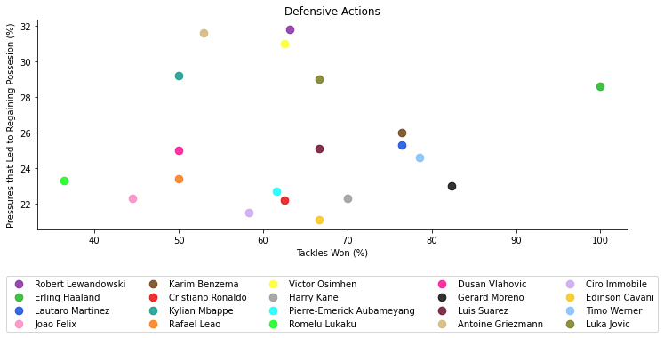

```python
#Created new column in the dataframe to look at tackle win percentage. #Created a plot with tackle win percentage
#against pressures that led to regaining possesion percentage.

OffBall['TacklesWinPercent'] = pd.to_numeric(OffBall['tackles_won'])/pd.to_numeric(OffBall['tackles']) *100
sns.lmplot(x="TacklesWinPercent", y="pressure_regain_pct", data=OffBall, fit_reg=False, hue='player', \
               legend=False, palette=new_palette, size=4, aspect=2.5, scatter_kws={"s": 75})
plt.legend(loc=9, bbox_to_anchor=(0.5, -0.2), ncol=5)
plt.title('Defensive Actions')
plt.xlabel('Tackles Won (%)')
plt.ylabel('Pressures that Led to Regaining Possesion (%)')
```

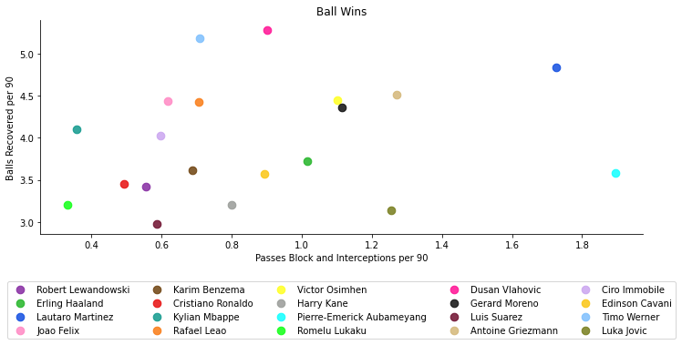

```python
#Created two new columns to look at the stats, blocked passes and interceptions per 90 minutes and ball recoveries per 90
#minutes instead of the raw numbers. Created a plot with blocked passes and interceptions per 90 minutes against ball
#recoveries per 90 minutes.

OffBall['blockint_per_90'] = (pd.to_numeric(OffBall['blocked_passes']) +
                              pd.to_numeric(OffBall['interceptions']))/pd.to_numeric(OffBall['minutes'])*90
OffBall['BallRecoveries_per_90'] = pd.to_numeric(OffBall['ball_recoveries'])/pd.to_numeric(OffBall['minutes'])*90
sns.lmplot(x="blockint_per_90", y="BallRecoveries_per_90", data=OffBall, fit_reg=False, hue='player', \
               legend=False, palette=new_palette, size=4, aspect=2.5, scatter_kws={"s": 75})
plt.legend(loc=9, bbox_to_anchor=(0.5, -0.2), ncol=5)
plt.title('Ball Wins')
plt.xlabel('Passes Block and Interceptions per 90')
plt.ylabel('Balls Recovered per 90')
```

The first plot depicts tackles won percentage and the percent of the pressures that leads to the team regaining possession. These two attributes are very important to City's playstyle when they out of the ball as the look to put pressure on the defenders to win back the ball as soon as possible. Putting pressure on the defenders mean they have to try and dribble around or make a pass quicker than they would like, the former plays into the tackles and winning the ball. The latter plays more into the second plot that put pass blocks and interception per 90 minutes against ball recoveries per 90 minutes. Ball recoveries may not be the best metric for strikers since as I said earlier it includes gathering possession in the defensive third so players in defensive styles may have skewed numbers so this stat will be taken with a grain of salt.

With all that in mind the top five for out of possession play are:

1) Antoine Griezmann 2) Victor Osimhen 3) Lautaro Martinez 4) Erling Haaland 5) Luka Jovic

### Physcial Attributes

What players do on the pitch is extremely important thing to consider when looking to bolster your squad but there are other important thing you need to consider too. Some of those include age, cost, and build. Aerials won and lost refer to balls in the air and battling other players for headers.

```python
#Displayed physical dataframe and sorted by height.

Physical.sort_values(by = 'height', ascending = False)
```

|  | player | value | age | height | aerials_won | aerials_lost |
| --- | --- | --- | --- | --- | --- | --- |
| 686 | Erling Haaland | 72000000 | 19 | 194 | 21 | 23 |
| 1055 | Romelu Lukaku | 68000000 | 26 | 191 | 83 | 73 |
| 836 | Dusan Vlahovic | 16000000 | 19 | 190 | 38 | 60 |
| 2341 | Harry Kane | 120000000 | 26 | 188 | 64 | 123 |
| 1550 | Rafael Leao | 20000000 | 20 | 188 | 30 | 33 |
| 79 | Pierre-Emerick Aubameyang | 56000000 | 30 | 187 | 37 | 59 |
| 1093 | Cristiano Ronaldo | 60000000 | 34 | 187 | 37 | 38 |
| 1298 | Victor Osimhen | 27000000 | 20 | 186 | 94 | 154 |
| 1139 | Ciro Immobile | 40000000 | 29 | 185 | 24 | 68 |
| 283 | Robert Lewandowski | 56000000 | 30 | 185 | 62 | 47 |
| 1925 | Karim Benzema | 32000000 | 31 | 184 | 28 | 48 |
| 1844 | Edinson Cavani | 20000000 | 32 | 184 | 4 | 6 |
| 265 | Luis Suarez | 28000000 | 32 | 182 | 5 | 7 |
| 1932 | Luka Jovic | 22000000 | 21 | 182 | 10 | 12 |
| 1920 | Timo Werner | 64000000 | 23 | 181 | 9 | 28 |
| 196 | Joao Felix | 81000000 | 19 | 180 | 16 | 48 |
| 2504 | Gerard Moreno | 16000000 | 27 | 180 | 54 | 85 |
| 1858 | Kylian Mbappe | 180000000 | 20 | 178 | 4 | 4 |
| 253 | Antoine Griezmann | 96000000 | 28 | 176 | 24 | 30 |
| 1056 | Lautaro Martinez | 64000000 | 21 | 174 | 26 | 62 |

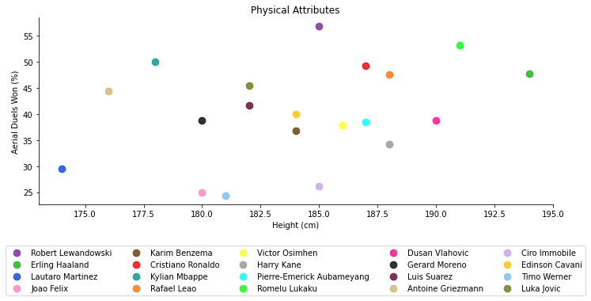

```python
#Created new column to look at aerial duel win percentage. Created a plot with height against aerial duel win percentage.

Physical['AerialWinPct'] = (pd.to_numeric(Physical['aerials_won'])/(pd.to_numeric(Physical['aerials_won']) +
                                                                    pd.to_numeric(Physical['aerials_lost']))) *100
sns.lmplot(x="height", y="AerialWinPct", data=Physical, fit_reg=False, hue='player', \
               legend=False, palette=new_palette, size=4, aspect=2.5, scatter_kws={"s": 75})
plt.legend(loc=9, bbox_to_anchor=(0.5, -0.2), ncol=5)
plt.title('Physical Attributes')
plt.xlabel('Height (cm)')
plt.ylabel('Aerial Duels Won (%)')
```

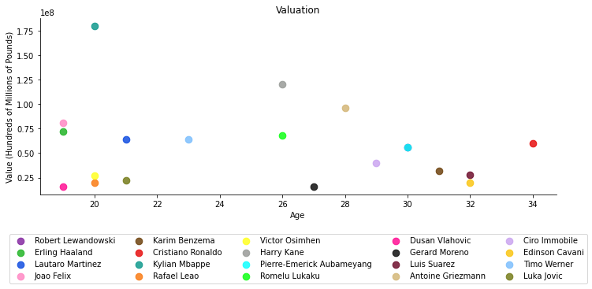

```python
#Created a plot with age against value.

sns.lmplot(x="age", y="value", data=Physical, fit_reg=False, hue='player', \
               legend=False, palette=new_palette, size=4, aspect=2.5, scatter_kws={"s": 75})
plt.legend(loc=9, bbox_to_anchor=(0.5, -0.2), ncol=5)
plt.title('Valuation')
plt.xlabel('Age')
plt.ylabel('Value (Hundreds of Millions of Pounds)')
```

The first plot shows height and aerial duel win percentage. I have stated before that City have to utilze crosses to find ways of scoring so being a big presence in the box is key to doing that. Manchester City also have a many good dribblers which means they win a lot of free kicks and they also have a lot of the ball in the opponents defensive third and have had the most corner kicks in the league with 8.19 per game. Sometimes they have to just clear the ball forward to beat a high press, so being tall and able to win the ball in the air is key in starting a new attack and relieve pressure. The second puts age up against value which focuses more on the business side of the transfer market rather than just looking at statistics from gamees. Both sides of the age spectrum have their values, young can have an extended stay at the club and older can bring experience and a locker room presence. City are in a position where they have a strong locker room with several leaders and with no striker in the squad currently a young star is exactly what the team needs. On the money side of things, City are considerably rich so having the least value is not as crucial as it could be for other teams but they are still looking to make good business and won't spend over the top prices. Note: Robert Lewandoski and Pierre-Emerick Aubameyang have the same age and value.

For this section the top five candidates are:

1) Erling Haaland 2) Rafael Leao 3) Romelu Lukaku 4) Dusan Vlahovic 5) Luka Jovic

## Top Option Overall

[figure not shown]

The top option for Manchester City to sign is Erling Haaland as he was in the top five of three of the metrics and was top in two of them, and the most important for his position, scoring. He may not of had the highest marks in keeping possession but as a striker he will not be having to do that as much as other players in his team. He also will have time to adjust after working with one of the best coaches in the world who will demand him to do this to get in the team on a consist basis. This conclusion was made after just looking at stats and sometimes stats do lie and need to be looked at in tandem with the eye test which is just watching the players and seeing things stats don't pick up on like positioning the or runs made that create space for other players.

A couple honorable mentions are Rafael Leao and Luka Jovic if circumstances prevent City from making a move for Haaland.

## Predicting Performance

Given that City it mostly the same team it was when Aguero left I used his expected goals per game to try and estimate what Haaland's goal per game will be. The reason I used Aguero's numbers is because Haaland will get similar amounts of chances, be in similar positions, and will have the same players feeding him those chances

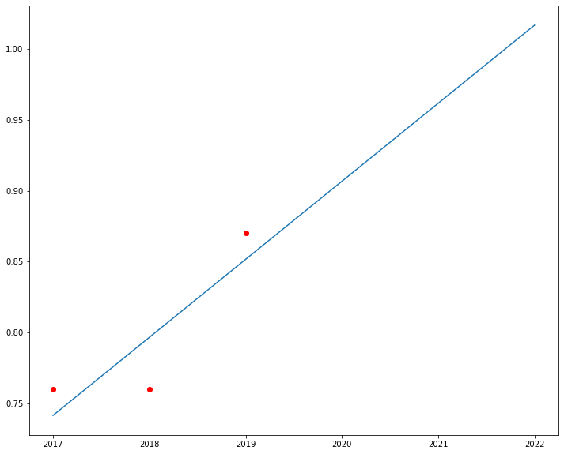

```python
#Using the data I made a regression line to estimate how many expected goals Haaland will have per game and plotted that
#line along with the actual points from Aguero's time.

years = np.array([2017, 2018, 2019])
newyears = np.array([2020, 2021, 2022])
xgper90 = np.array([.76, .76, .87])
x, y = np.polyfit(years, xgper90, 1)
plt.figure(figsize = (12, 10))
plt.plot(years, xgper90, 'o', color = 'red')
plt.xticks(ticks = [2017, 2018, 2019, 2020, 2021, 2022])
years = np.append(years, newyears)
plt.plot(years, x*years+y)
Haaland = Scoring.loc[Scoring['player'] == 'Erling Haaland']
```

```python
#Adding the predicted expected goals for Haaland to his expected goals net per 90 to estimate his goals per 90 in the
#next three seasons.

xgnetper90 = pd.to_numeric(Haaland['xg_net'])/pd.to_numeric(Haaland['minutes'])*90
Haalandgp90 = (x*newyears+y)
for i in range(0,3):
    Haalandgp90[i] += xgnetper90
Haalandgp90
```

```
array([1.32153026, 1.37653026, 1.43153026])
```

With the ouput above it looks like Haaland would be set for success in the Manchester City system and will be given plenty of chances to feast on if he made the move to Manchester.